# Case Study 02

contributed by Ramesh and gino

December 08, 2016

## Introduction

Case Study 02, final case study.

- installation and loading of necessary packages
- R version

```r
knitr::opts_chunk$set(echo = TRUE)
knitr::opts_knit$set(root.dir = "~/git/MSDS6306/CaseStudy02/Analysis/Data")
require(tseries)
require(ggplot2)
require(sqldf)
require(lubridate)
require(tcltk)
```

### **Question 1**

#### **Create the X matrix and print it from SAS, R, and Python.**

#### SAS Code

```sas
data mylib.Xmatrix;
input x0 x1 x2 x3;
datalines;
4 5 1 2
1 0 3 5
2 1 8 2
;
run;
quit;

Proc IML;
use mylib.Xmatrix;
read all;
x = x0 || x1 || x2 || x3;
print x;
run;
quit;
```

[figure not shown]

#### R Code

```r
new_vector <- c(4,5,1,2,1,0,3,5,2,1,8,2)
X <- matrix(new_vector, ncol=4, nrow=3, byrow=TRUE)
X
```

```
##      [,1] [,2] [,3] [,4]
## [1,]    4    5    1    2
## [2,]    1    0    3    5
## [3,]    2    1    8    2
```

#### Python Code

```python
import numpy as np

new_array = np.array([4,5,1,2,1,0,3,5,2,1,8,2])
new_matrix = np.matrix(new_array)
X = new_matrix.reshape(3,4)
print(X)
```

[figure not shown]

### **Question 2**

#### **Please do the following with your assigned stock. “ADP”**

#### **Download “ADP” data.**

```r
ADP_data <- get.hist.quote('ADP',quote="Close")
```

```
## time series ends   2016-11-25
```

#### **Calculate log returns.**

```r
ADP_return <- log(lag(ADP_data)) - log(ADP_data)
ADP_volatility <- sd(ADP_return) * sqrt(250) * 100
```

#### **Calculate volatility measure.**

```r
getVol <- function(d, log_returns){
  var = 0
  lam = 0
  varlist <- c()

  for (r in log_returns) {
    lam = lam*(1 - 1/d) + 1
    var = (1 - 1/lam)*var + (1/lam)*r^2
    varlist <- c(varlist, var)
  }
  sqrt(varlist)
}
```

#### **Calculate volatility over entire length of series for various three different decay factors.**

```r
volest <- getVol(10,ADP_return)
volest2 <- getVol(30,ADP_return)
volest3 <- getVol(100,ADP_return)
```

#### **Plot the results, overlaying the volatility curves on the data, just as was done in the S&P example.**

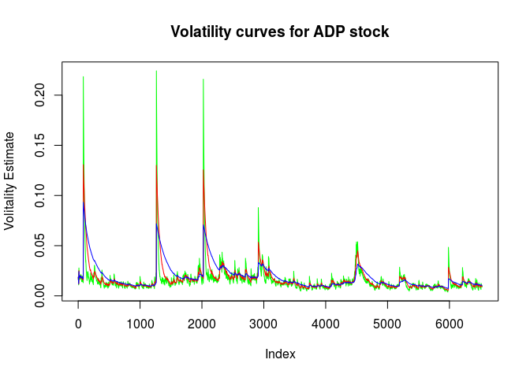

```r
plot(volest, type="l", col="green", main="Volatility curves for ADP stock", ylab = "Volitality Estimate")
lines(volest2,type="l",col="red")
lines(volest3, type = "l", col="blue")
```

### **Question 3**

#### **The built-in data set called Orange in R is about the growth of orange trees. The Orange data frame has 3 columns of records of the growth of orange trees.**

#### **a) Calculate the mean and the median of the trunk circumferences for different size of the trees. (Tree)**

```r
data("Orange")
head(Orange)
```

```
##   Tree  age circumference
## 1    1  118            30
## 2    1  484            58
## 3    1  664            87
## 4    1 1004           115
## 5    1 1231           120
## 6    1 1372           142
```

```r
str(Orange)
```

```
## Classes 'nfnGroupedData', 'nfGroupedData', 'groupedData' and 'data.frame':   35 obs. of  3 variables:
##  $ Tree         : Ord.factor w/ 5 levels "3"<"1"<"5"<"2"<..: 2 2 2 2 2 2 2 4 4 4 ...
##  $ age          : num  118 484 664 1004 1231 ...
##  $ circumference: num  30 58 87 115 120 142 145 33 69 111 ...
##  - attr(*, "formula")=Class 'formula' length 3 circumference ~ age | Tree
##   .. ..- attr(*, ".Environment")=<environment: R_EmptyEnv>
##  - attr(*, "labels")=List of 2
##   ..$ x: chr "Time since December 31, 1968"
##   ..$ y: chr "Trunk circumference"
##  - attr(*, "units")=List of 2
##   ..$ x: chr "(days)"
##   ..$ y: chr "(mm)"
```

```r
summary(Orange)
```

```
##  Tree       age         circumference
##  3:7   Min.   : 118.0   Min.   : 30.0
##  1:7   1st Qu.: 484.0   1st Qu.: 65.5
##  5:7   Median :1004.0   Median :115.0
##  2:7   Mean   : 922.1   Mean   :115.9
##  4:7   3rd Qu.:1372.0   3rd Qu.:161.5
##        Max.   :1582.0   Max.   :214.0
```

```r
#Mean of circumference by Tree size
orange_mean <- tapply(Orange$circumference,Orange$Tree,mean)
orange_mean[order(names(orange_mean))]
```

```
##         1         2         3         4         5
##  99.57143 135.28571  94.00000 139.28571 111.14286
```

```r
#Median of circumference by Tree size
orange_median <- tapply(Orange$circumference,Orange$Tree,median)
orange_median[order(names(orange_median))]
```

```
##   1   2   3   4   5
## 115 156 108 167 125
```

#### **b) Make a scatter plot of the trunk circumferences against the age of the tree. Use different plotting symbols for different size of trees.**

```r
is.numeric(Orange$Tree)
```

```
## [1] FALSE
```

```r
is.factor(Orange$Tree)
```

```
## [1] TRUE
```

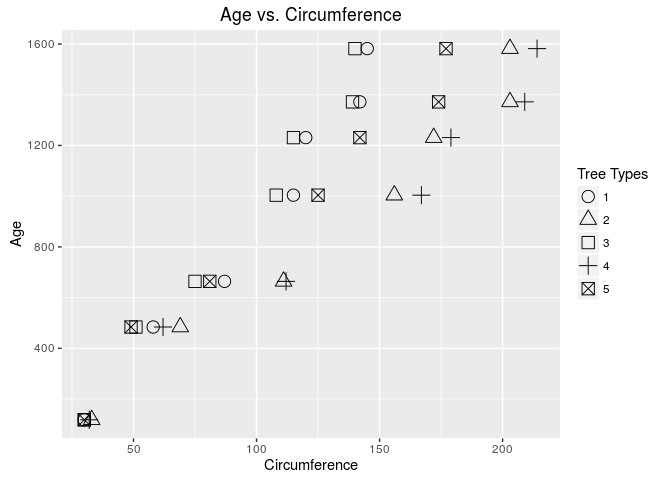

```r
Orange$order.tree <- as.numeric(as.character(Orange$Tree))

ggplot(data=Orange, aes(x=Orange$circumference, y=Orange$age)) +
  geom_point(aes(shape = reorder(Orange$Tree,Orange$order.tree)), size=4) +
  scale_shape(name="Tree Types", solid = FALSE) +
  ggtitle("Age vs. Circumference") + xlab("Circumference") + ylab("Age")
```

#### **c) Display the trunk circumferences on a comparative boxplot against tree. Be sure you order the boxplots in the increasing order of maximum diameter.**

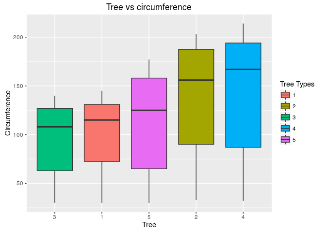

```r
  ggplot(Orange, aes(reorder(Orange$Tree,Orange$circumference) , Orange$circumference, fill = reorder(Orange$Tree,Orange$order.tree))) +
 geom_boxplot() +
    guides(fill = guide_legend(title = "Tree Types"))+
  ggtitle("Tree vs circumference") +
  xlab("Tree") +  ylab("Circumference")
```

### **Question 4**

#### **Download “Temp” data set**

#### **Clean TEMP.csv data to get “Date” into one consistant format, before analysis can begin**

```r
#load TEMP.csv file
temp_data <- read.csv("TEMP.csv",header=TRUE)
head(temp_data)
```

```
##         Date Monthly.AverageTemp Monthly.AverageTemp.Uncertainty
## 1 1838-04-01              13.008                           2.586
## 2 1838-05-01                  NA                              NA
## 3 1838-06-01              23.950                           2.510
## 4 1838-07-01              26.877                           2.883
## 5 1838-08-01              24.938                           2.992
## 6 1838-09-01              18.981                           2.538
##       Country
## 1 Afghanistan
## 2 Afghanistan
## 3 Afghanistan
## 4 Afghanistan
## 5 Afghanistan
## 6 Afghanistan
```

```r
#Any data set that is "NA" has been removed across the board
temp_data <- temp_data[complete.cases(temp_data),]

#cleaning up date format
temp_data$date.clean <- as.Date(temp_data$Date, format = "%Y-%m-%d")
temp_data.sub <- subset(temp_data,is.na(temp_data$date.clean))
temp_data.sub02 <- subset(temp_data,!is.na(temp_data$date.clean))
temp_data.sub$date.clean <- format(dmy(temp_data.sub$Date),"%Y-%m-%d")
temp_data.sub$date.clean <- as.Date(temp_data.sub$date.clean, format = "%Y-%m-%d")

#combining the 2 data set
final_temp_data <- rbind(temp_data.sub,temp_data.sub02)

#write to a clean file
write.csv(final_temp_data,"final_temp_data.csv")
remove(list = ls())

#loading a clean file for analysis
final_temp_data <- read.csv("final_temp_data.csv",header=TRUE)
head(final_temp_data)
```

```
##     X     Date Monthly.AverageTemp Monthly.AverageTemp.Uncertainty
## 1 742 1/1/1900              -3.428                           0.936
## 2 743 2/1/1900               1.234                           1.135
## 3 744 3/1/1900              10.545                           0.933
## 4 745 4/1/1900              13.352                           0.536
## 5 746 5/1/1900              20.260                           0.524
## 6 747 6/1/1900              24.448                           0.944
##       Country date.clean
## 1 Afghanistan 1900-01-01
## 2 Afghanistan 1900-01-02
## 3 Afghanistan 1900-01-03
## 4 Afghanistan 1900-01-04
## 5 Afghanistan 1900-01-05
## 6 Afghanistan 1900-01-06
```

#### **(i) Find the difference between the maximum and the minimum monthly average temperatures for each country and report/visualize top 20 countries with the maximum differences for the period since 1900.**

```r
#removing unwanted rows
final_temp_data <- subset(final_temp_data,select = c("Date","Monthly.AverageTemp","Monthly.AverageTemp.Uncertainty","Country","date.clean"))

#verifying date formats
final_temp_data$date.clean <-  as.Date(final_temp_data$date.clean)
final_temp_data$date.month <- format(as.Date(final_temp_data$date.clean), "%d")
final_temp_data$date.year <- format(as.Date(final_temp_data$date.clean), "%Y")

#filtering to data sets > 1900
final_temp_data02 <- subset(final_temp_data,final_temp_data$date.clean > '1900-12-31')

#grouping by country for plot and analysis
temp_country <- sqldf("SELECT Country, (max([Monthly.AverageTemp])) as maxtemp, (min([Monthly.AverageTemp])) as mintemp, (max([Monthly.AverageTemp])) - (min([Monthly.AverageTemp])) as tempdiff  FROM final_temp_data02 Group by Country")
top20_max_temp <- sqldf("Select src.Country, src.MaxTempDiff From (SELECT Country, max(tempDiff) MaxTempDiff FROM temp_country group by Country) src order by src.MaxTempdiff DESC LIMIT 20")
```

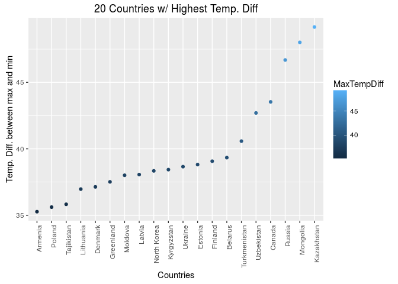

```r
#filtering data set for United states and date range greater than 1990
ustemp <- subset(final_temp_data02,(final_temp_data02$Country=="United States") & (final_temp_data02$date.clean >= "1990-01-01"))

#plot 01
ggplot(data=top20_max_temp, aes(x=reorder(top20_max_temp$Country,top20_max_temp$MaxTempDiff ), y=top20_max_temp$MaxTempDiff , colour =MaxTempDiff)) +
  geom_point()+
  ggtitle("20 Countries w/ Highest Temp. Diff") + xlab("Countries") + ylab("Temp. Diff. between max and min") +
  theme(axis.text.x = element_text(angle = 90, hjust = 1))
```

#### **(ii) Select a subset of data called “UStemp” where US land temperatures from 01/01/1990 in Temp data. Use UStemp dataset to answer the followings.**

```r
#getfahrenheit function takes in celsius and returns fahrenheit
getfahrenheit <- function(Celsius){
  return(round(((Celsius*(9/5)) + 32), digits = 3))
  }
```

#### **a) Create a new column to display the monthly average land temperatures in Fahrenheit (°F).**

```r
#converting celsius to fahrenheit
ustemp$fahrenheit <- getfahrenheit(ustemp$Monthly.AverageTemp)
head(ustemp)
```

```
##            Date Monthly.AverageTemp Monthly.AverageTemp.Uncertainty
## 314893 1/1/1990              -1.123                           0.195
## 314894 2/1/1990              -1.747                           0.107
## 314895 3/1/1990               4.465                           0.240
## 314896 4/1/1990               9.380                           0.080
## 314897 5/1/1990              13.772                           0.112
## 314898 6/1/1990              19.780                           0.255
##              Country date.clean date.month date.year fahrenheit
## 314893 United States 1990-01-01         01      1990     29.979
## 314894 United States 1990-01-02         02      1990     28.855
## 314895 United States 1990-01-03         03      1990     40.037
## 314896 United States 1990-01-04         04      1990     48.884
## 314897 United States 1990-01-05         05      1990     56.790
## 314898 United States 1990-01-06         06      1990     67.604
```

#### **b) Calculate average land temperature by year and plot it. The original file has the average land temperature by month.**

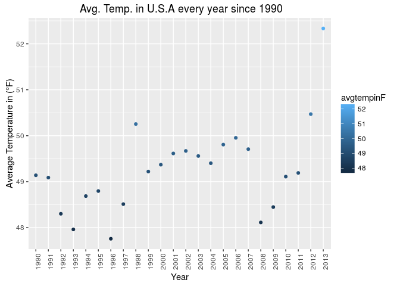

```r
#preparing data set for analysis
usa_temp_year <- sqldf("SELECT Country, [date.year], avg([Monthly.AverageTemp]) as avgtemp, avg(fahrenheit) as avgtempinF FROM ustemp Group by [date.year]")

#plot 02
ggplot(usa_temp_year, aes(x=usa_temp_year$date.year, y=usa_temp_year$avgtempinF, color=avgtempinF) ) +
  geom_point()+
  ggtitle(" Avg. Temp. in U.S.A every year since 1990") + xlab("Year") + ylab("Average Temperature in (°F)") +
  theme(axis.text.x = element_text(angle = 90, hjust = 1))
```

#### **c) Calculate the one year difference of average land temperature by year and provide the maximum difference (value) with corresponding two years.**

```r
# temperature (°C)
i=1
tempdiff=numeric(0)
tempdiff=0
  for (i in 2:NROW(usa_temp_year)){
   tempdiff = abs(usa_temp_year[i,]$avgtemp-usa_temp_year[(i-1),]$avgtemp)
  usa_temp_year$avgdifftemp[i] <- tempdiff
  }

usa_temp_year$avgdifftemp[is.na(usa_temp_year$avgdifftemp)] <- 0

# temperature (°F)
i=1
tempdiffF=numeric(0)
tempdiffF=0
  for (i in 2:NROW(usa_temp_year)){
   tempdiffF = abs(usa_temp_year[i,]$avgtempinF-usa_temp_year[(i-1),]$avgtempinF)
  usa_temp_year$avgdifftempF[i] <- tempdiffF
  }

usa_temp_year$avgdifftempF[is.na(usa_temp_year$avgdifftempF)] <- 0

head(usa_temp_year)
```

```
##         Country date.year  avgtemp avgtempinF avgdifftemp avgdifftempF
## 1 United States      1990 9.521583   49.13900  0.00000000   0.00000000
## 2 United States      1991 9.493667   49.08858  0.02791667   0.05041667
## 3 United States      1992 9.056333   48.30150  0.43733333   0.78708333
## 4 United States      1993 8.867250   47.96100  0.18908333   0.34050000
## 5 United States      1994 9.270333   48.68658  0.40308333   0.72558333
## 6 United States      1995 9.331000   48.79583  0.06066667   0.10925000
```

- maximum difference (value)

```r
#max temperature difference in F
max(usa_temp_year$avgdifftempF)
```

```
## [1] 1.864556
```

```r
#max temperature difference in C
max(usa_temp_year$avgdifftemp)
```

```
## [1] 1.036028
```

**Plotting by Year and Temperature Difference in U.S.A**

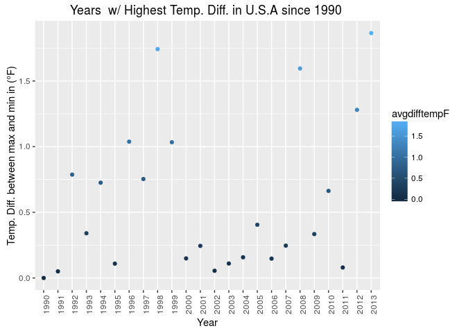

```r
#plot
ggplot(usa_temp_year, aes(x=usa_temp_year$date.year, y=usa_temp_year$avgdifftempF, color=avgdifftempF) ) +
  geom_point()+
  ggtitle("Years  w/ Highest Temp. Diff. in U.S.A since 1990 ") + xlab("Year") + ylab("Temp. Diff. between max and min in (°F)") +
  theme(axis.text.x = element_text(angle = 90, hjust = 1))
```

```r
#cleanup before city analysis
remove(list = ls())
```

#### **(iii) Download “CityTemp” data set (check your SMU email). Find the difference between the maximum and the minimum temperatures for each major city and report/visualize top 20 cities with maximum differences for the period since 1900.**

```r
#load city data
city.temp <- read.csv("CityTemp.csv",header=TRUE)
head(city.temp)
```

```
##         Date Monthly.AverageTemp Monthly.AverageTemp.Uncertainty
## 1 1850-01-01              15.986                           1.537
## 2 1850-02-01              18.345                           1.527
## 3 1850-03-01              18.632                           2.162
## 4 1850-04-01              18.154                           1.693
## 5 1850-05-01              17.480                           1.237
## 6 1850-06-01              17.183                           1.252
##          City  Country Latitude Longitude
## 1 Addis Abeba Ethiopia    8.84N    38.11E
## 2 Addis Abeba Ethiopia    8.84N    38.11E
## 3 Addis Abeba Ethiopia    8.84N    38.11E
## 4 Addis Abeba Ethiopia    8.84N    38.11E
## 5 Addis Abeba Ethiopia    8.84N    38.11E
## 6 Addis Abeba Ethiopia    8.84N    38.11E
```

```r
#Any data set that is "NA" has been removed across the board
city.temp <- city.temp[complete.cases(city.temp),]

#cleaning up date format
city.temp$date.clean <- as.Date(city.temp$Date, format = "%Y-%m-%d")
city.temp.sub <- subset(city.temp,is.na(city.temp$date.clean))
city.temp.sub02 <- subset(city.temp,!is.na(city.temp$date.clean))
city.temp.sub$date.clean <- format(dmy(city.temp.sub$Date),"%Y-%m-%d")
city.temp.sub$date.clean <- as.Date(city.temp.sub$date.clean, format = "%Y-%m-%d")

#combining the 2 data set
final_city_temp <- rbind(city.temp.sub,city.temp.sub02)

#write to a clean file
write.csv(final_city_temp,"final_city_temp.csv")
remove(list = ls())

#loading a clean file for analysis
final_city_temp <- read.csv("final_city_temp.csv",header=TRUE)
head(final_city_temp)
```

```
##     X     Date Monthly.AverageTemp Monthly.AverageTemp.Uncertainty
## 1 601 1/1/1900              17.019                           1.073
## 2 602 2/1/1900              18.153                           0.772
## 3 603 3/1/1900              19.110                           0.954
## 4 604 4/1/1900              19.492                           0.887
## 5 605 5/1/1900              18.353                           2.247
## 6 606 6/1/1900              17.619                           0.948
##          City  Country Latitude Longitude date.clean
## 1 Addis Abeba Ethiopia    8.84N    38.11E 1900-01-01
## 2 Addis Abeba Ethiopia    8.84N    38.11E 1900-01-02
## 3 Addis Abeba Ethiopia    8.84N    38.11E 1900-01-03
## 4 Addis Abeba Ethiopia    8.84N    38.11E 1900-01-04
## 5 Addis Abeba Ethiopia    8.84N    38.11E 1900-01-05
## 6 Addis Abeba Ethiopia    8.84N    38.11E 1900-01-06
```

```r
#remove unwanted rows

final_city_temp <- subset(final_city_temp,select = c("Date","Monthly.AverageTemp","Monthly.AverageTemp.Uncertainty","City","date.clean"))
final_city_temp$date.clean <-  as.Date(final_city_temp$date.clean)
final_city_temp$date.month <- format(as.Date(final_city_temp$date.clean), "%d")
final_city_temp$date.year <- format(as.Date(final_city_temp$date.clean), "%Y")
final_city_temp02 <- subset(final_city_temp,final_city_temp$date.clean > '1900-12-31')


temp_city <- sqldf("SELECT City, (max([Monthly.AverageTemp])) as maxtemp, (min([Monthly.AverageTemp])) as mintemp, (max([Monthly.AverageTemp])) - (min([Monthly.AverageTemp])) as tempdiff  FROM final_city_temp02 Group by City")
top20_city_temp <- sqldf("Select src.City, src.MaxTempDiff From (SELECT City, max(tempDiff) MaxTempDiff FROM temp_city group by City) src order by src.MaxTempdiff DESC LIMIT 20")
```

**Plotting Top 20 Cities with Temperature Difference in the world**

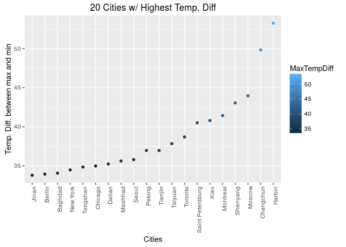

```r
ggplot(data=top20_city_temp, aes(x=reorder(top20_city_temp$City,top20_city_temp$MaxTempDiff ), y=top20_city_temp$MaxTempDiff , colour =MaxTempDiff)) +
  geom_point()+
  ggtitle("20 Cities w/ Highest Temp. Diff") + xlab("Cities") + ylab("Temp. Diff. between max and min") +
  theme(axis.text.x = element_text(angle = 90, hjust = 1))
```

```r
remove(list = ls())
```